# Problem Statement (Brief)

Your client is a retail banking institution. Term deposits are a major source of income for a bank. A term deposit is a cash investment held at a financial institution. Your money is invested for an agreed rate of interest over a fixed amount of time, or term. The bank has various outreach plans to sell term deposits to their customers such as email marketing, advertisements, telephonic marketing and digital marketing. Telephonic marketing campaigns still remain one of the most effective way to reach out to people. However, they require huge investment as large call centers are hired to actually execute these campaigns. Hence, it is crucial to identify the customers most likely to convert beforehand so that they can be specifically targeted via call. You are provided with the client data such as : age of the client, their job type, their marital status, etc. Along with the client data, you are also provided with the information of the call such as the duration of the call, day and month of the call, etc. Given this information, your task is to predict if the client will subscribe to term deposit. You are provided with following files: 1.train.csv : Use this dataset to train the model. This file contains all the client and call details as well as the target variable “subscribed”. You have to train your model using this file. 2.test.csv : Use the trained model to predict whether a new set of clients will subscribe the term deposit.

# Problem Statement (In Short)

Given data of sales of term deposits of a bank. ('ID', 'age', 'job', 'marital', 'education', 'default', 'balance', 'housing', 'loan', 'contact', 'day', 'month', 'duration', 'campaign', 'pdays', 'previous', 'poutcome', 'subscribed') predict each client will subscribe or not in unseen dataset.

# Importing libraries

```python
import numpy as np
import pandas as pd
from datetime import datetime
from datetime import date
import calendar
import matplotlib.pyplot as plt
import seaborn as sn
%matplotlib inline
```

# Importing data

```python
train = pd.read_csv('ftrain.csv')
test = pd.read_csv('ftest.csv')
```

# Dimensions of data

```python
train.shape
```

```
(31647, 18)
```

```python
test.shape
```

```
(13564, 17)
```

Samples of data

```python
train.head()
```

|  | ID | age | job | marital | education | default | balance | housing | loan | contact | day | month | duration | campaign | pdays | previous | poutcome | subscribed |
| --- | --- | --- | --- | --- | --- | --- | --- | --- | --- | --- | --- | --- | --- | --- | --- | --- | --- | --- |
| 0 | 26110 | 56 | admin. | married | unknown | no | 1933 | no | no | telephone | 19 | nov | 44 | 2 | -1 | 0 | unknown | no |
| 1 | 40576 | 31 | unknown | married | secondary | no | 3 | no | no | cellular | 20 | jul | 91 | 2 | -1 | 0 | unknown | no |
| 2 | 15320 | 27 | services | married | secondary | no | 891 | yes | no | cellular | 18 | jul | 240 | 1 | -1 | 0 | unknown | no |
| 3 | 43962 | 57 | management | divorced | tertiary | no | 3287 | no | no | cellular | 22 | jun | 867 | 1 | 84 | 3 | success | yes |
| 4 | 29842 | 31 | technician | married | secondary | no | 119 | yes | no | cellular | 4 | feb | 380 | 1 | -1 | 0 | unknown | no |

```python
test.head()
```

|  | ID | age | job | marital | education | default | balance | housing | loan | contact | day | month | duration | campaign | pdays | previous | poutcome |
| --- | --- | --- | --- | --- | --- | --- | --- | --- | --- | --- | --- | --- | --- | --- | --- | --- | --- |
| 0 | 38441 | 32 | services | married | secondary | no | 118 | yes | no | cellular | 15 | may | 20 | 6 | -1 | 0 | unknown |
| 1 | 40403 | 78 | retired | divorced | primary | no | 2787 | no | no | telephone | 1 | jul | 372 | 1 | -1 | 0 | unknown |
| 2 | 3709 | 31 | self-employed | single | tertiary | no | 144 | yes | no | unknown | 16 | may | 676 | 1 | -1 | 0 | unknown |
| 3 | 37422 | 57 | services | single | primary | no | 3777 | yes | no | telephone | 13 | may | 65 | 2 | -1 | 0 | unknown |
| 4 | 12527 | 45 | blue-collar | divorced | secondary | no | -705 | no | yes | unknown | 3 | jul | 111 | 1 | -1 | 0 | unknown |

# Overview of data

```python
train.columns
```

```
Index(['ID', 'age', 'job', 'marital', 'education', 'default', 'balance',
       'housing', 'loan', 'contact', 'day', 'month', 'duration', 'campaign',
       'pdays', 'previous', 'poutcome', 'subscribed'],
      dtype='object')
```

```python
test.columns
```

```
Index(['ID', 'age', 'job', 'marital', 'education', 'default', 'balance',
       'housing', 'loan', 'contact', 'day', 'month', 'duration', 'campaign',
       'pdays', 'previous', 'poutcome'],
      dtype='object')
```

```python
train.dtypes
```

```
ID             int64
age            int64
job           object
marital       object
education     object
default       object
balance        int64
housing       object
loan          object
contact       object
day            int64
month         object
duration       int64
campaign       int64
pdays          int64
previous       int64
poutcome      object
subscribed    object
dtype: object
```

```python
test.dtypes
```

```
ID            int64
age           int64
job          object
marital      object
education    object
default      object
balance       int64
housing      object
loan         object
contact      object
day           int64
month        object
duration      int64
campaign      int64
pdays         int64
previous      int64
poutcome     object
dtype: object
```

# Univariate Analysis

```python
train["subscribed"].value_counts()
```

```
no     27932
yes     3715
Name: subscribed, dtype: int64
```

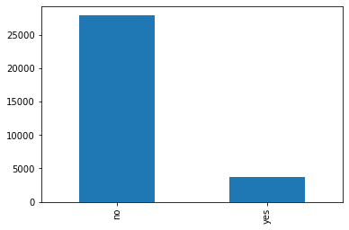

```python
train["subscribed"].value_counts().plot.bar()
```

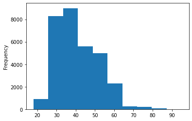

```python
train["age"].plot.hist()
```

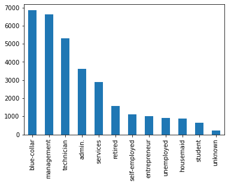

```python
train["job"].value_counts().plot.bar()
```

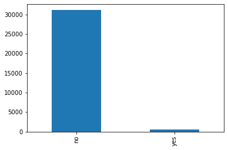

```python
train["default"].value_counts().plot.bar()
```

# Bivariate Analysis

```python
pd.crosstab(train['job'],train['subscribed'])
```

| subscribed job | no | yes |
| --- | --- | --- |
| admin. | 3179 | 452 |
| blue-collar | 6353 | 489 |
| entrepreneur | 923 | 85 |
| housemaid | 795 | 79 |
| management | 5716 | 923 |
| retired | 1212 | 362 |
| self-employed | 983 | 140 |
| services | 2649 | 254 |
| student | 453 | 182 |
| technician | 4713 | 594 |
| unemployed | 776 | 129 |
| unknown | 180 | 26 |

```python
pd.crosstab(train['default'],train['subscribed'])
```

| subscribed default | no | yes |
| --- | --- | --- |
| no | 27388 | 3674 |
| yes | 544 | 41 |

```python
train['subscribed'].replace('no', 0,inplace=True)
train['subscribed'].replace('yes', 1,inplace=True)
```

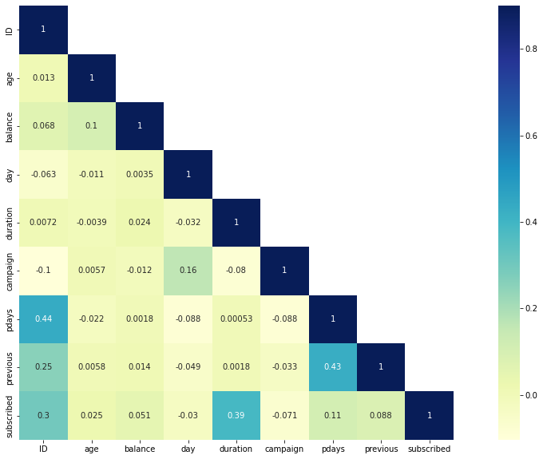

```python
corr = train.corr()
mask = np.array(corr)
mask[np.tril_indices_from(mask)] = False
fig,ax= plt.subplots()
fig.set_size_inches(20,10)
sn.heatmap(corr, mask=mask,vmax=.9, square=True,annot=True, cmap="YlGnBu")
```

# Missing value Analysis

```python
train.isnull().sum()
```

```
ID            0
age           0
job           0
marital       0
education     0
default       0
balance       0
housing       0
loan          0
contact       0
day           0
month         0
duration      0
campaign      0
pdays         0
previous      0
poutcome      0
subscribed    0
dtype: int64
```

No missing values

```python
test.isnull().sum()
```

```
ID           0
age          0
job          0
marital      0
education    0
default      0
balance      0
housing      0
loan         0
contact      0
day          0
month        0
duration     0
campaign     0
pdays        0
previous     0
poutcome     0
dtype: int64
```

No missing values

# Model Building

```python
target = train['subscribed']
train = train.drop('subscribed',1)
```

```
C:\Users\aatif mohammad\AppData\Local\Temp/ipykernel_18476/461833753.py:2: FutureWarning: In a future version of pandas all arguments of DataFrame.drop except for the argument 'labels' will be keyword-only
  train = train.drop('subscribed',1)
```

```python
# applying dummies on the train dataset
train = pd.get_dummies(train)
```

```python
from sklearn.model_selection import train_test_split
```

```python
# splitting into train and validation with 20% data in validation set and 80% data in train set.
X_train, X_val, y_train, y_val = train_test_split(train, target, test_size = 0.2, random_state=12)
```

# Logistic Regression

i.e, traget var is categorical

```python
from sklearn.linear_model import LogisticRegression
```

```python
LR = LogisticRegression()
```

```python
LR.fit(X_train,y_train)
```

[output not shown]

```
LogisticRegression()
```

```python
prediction = LR.predict(X_val)
```

# Evaluation

```python
from sklearn.metrics import accuracy_score
```

```python
# calculating the accuracy score
accuracy_score(y_val, prediction)
```

```
0.8906793048973144
```

Good Accuracy

# Decision Tree

```python
from sklearn.tree import DecisionTreeClassifier
```

```python
clf = DecisionTreeClassifier(max_depth=4, random_state=0)
```

```python
clf.fit(X_train,y_train)
```

```
DecisionTreeClassifier(max_depth=4, random_state=0)
```

```python
predict = clf.predict(X_val)
```

# Evaluation

```python
accuracy_score(y_val, predict)
```

```
0.9042654028436019
```

Good Accuarcy

# Prediction

```python
test = pd.get_dummies(test)
```

```python
test_prediction = clf.predict(test)
```

Fetching Results

```python
submission = pd.DataFrame()
submission['ID'] = test['ID']
submission['subscribed'] = test_prediction
submission['subscribed'].replace(0,'no',inplace=True)
submission['subscribed'].replace(1,'yes',inplace=True)
```

```python
submission.to_csv('predictions.csv', header=True, index=False)
```

```python
a=pd.read_csv('predictions.xlsx')
a.head(25)
```

[output not shown]